# ETM58D Business Analytics Homework 2

Mehmet Arda Keskin

2021-06-07

# 1 Setup and Loading Libraries

```r
knitr::opts_chunk$set(echo = TRUE, include = TRUE,fig.align = "center")
options(scipen = 999, knitr.kable.NA = "")

##install.packages("tidyverse")
##install.packages("lubridate")
##install.packages("readxl")
##install.packages("magrittr")
##install.packages("scatterplot3d")
##install.packages("ggfortify")

library(tidyverse)
library(lubridate)
library(readxl)
library(magrittr)
library(scatterplot3d)
library(ggfortify)
```

# 2 TASK 1

Importing the csv file which show distance between the cities of Turkey.

```r
df_t1 <- read_csv("HW2_q1_data.csv") %>% as_tibble()
head(df_t1)
```

```
## # A tibble: 6 x 81
##   ADANA ADIYAMAN AFYON `A–RI` AMASYA ANKARA ANTALYA `ARTV›N` AYDIN `BALIKES›R`
##   <dbl>    <dbl> <dbl>  <dbl>  <dbl>  <dbl>   <dbl>    <dbl> <dbl>       <dbl>
## 1    NA      336   573    966    611    490     557     1034   883         901
## 2   336       NA   909    646    632    755     893      755  1219        1237
## 3   573      909    NA   1310    589    256     292     1237   346         328
## 4   966      646  1310     NA    738   1054    1429      397  1642        1571
## 5   611      632   589    738     NA    333     825      696   931         833
## 6   490      755   256   1054    333     NA     544      981   598         535
## # … with 71 more variables: B›LEC›K <dbl>, B›NG÷L <dbl>, B›TL›S <dbl>,
## #   BOLU <dbl>, BURDUR <dbl>, BURSA <dbl>, «ANAKKALE <dbl>, «ANKIRI <dbl>,
## #   «ORUM <dbl>, DEN›ZL› <dbl>, D›YARBAKIR <dbl>, ED›RNE <dbl>, ELAZI– <dbl>,
## #   ERZ›NCAN <dbl>, ERZURUM <dbl>, ESK›ﬁEH›R <dbl>, GAZ›ANTEP <dbl>,
## #   G›RESUN <dbl>, G‹M‹ﬁHANE <dbl>, HAKKAR› <dbl>, HATAY <dbl>, ISPARTA <dbl>,
## #   ›«EL <dbl>, ›STANBUL <dbl>, ›ZM›R <dbl>, KARS <dbl>, KASTAMONU <dbl>,
## #   KAYSER› <dbl>, KIRKLAREL› <dbl>, KIRﬁEH›R <dbl>, KOCAEL› <dbl>,
## #   KONYA <dbl>, K‹TAHYA <dbl>, MALATYA <dbl>, MAN›SA <dbl>,
## #   KAHRAMANMARAﬁ <dbl>, MARD›N <dbl>, MU–LA <dbl>, MUﬁ <dbl>, NEVﬁEH›R <dbl>,
## #   N›–DE <dbl>, ORDU <dbl>, R›ZE <dbl>, SAKARYA <dbl>, SAMSUN <dbl>,
## #   S››RT <dbl>, S›NOP <dbl>, S›VAS <dbl>, TEK›RDA– <dbl>, TOKAT <dbl>,
## #   TRABZON <dbl>, TUNCEL› <dbl>, ﬁANLIURFA <dbl>, UﬁAK <dbl>, VAN <dbl>,
## #   YOZGAT <dbl>, ZONGULDAK <dbl>, AKSARAY <dbl>, BAYBURT <dbl>, KARAMAN <dbl>,
## #   KIRIKKALE <dbl>, BATMAN <dbl>, ﬁIRNAK <dbl>, BARTIN <dbl>, ARDAHAN <dbl>,
## #   I–DIR <dbl>, YALOVA <dbl>, KARAB‹K <dbl>, K›L›S <dbl>, OSMAN›YE <dbl>,
## #   D‹ZCE <dbl>
```

Replacing NAs with zeros (0)

```r
df_t1[is.na(df_t1)] <- 0
head(df_t1)
```

```
## # A tibble: 6 x 81
##   ADANA ADIYAMAN AFYON `A–RI` AMASYA ANKARA ANTALYA `ARTV›N` AYDIN `BALIKES›R`
##   <dbl>    <dbl> <dbl>  <dbl>  <dbl>  <dbl>   <dbl>    <dbl> <dbl>       <dbl>
## 1     0      336   573    966    611    490     557     1034   883         901
## 2   336        0   909    646    632    755     893      755  1219        1237
## 3   573      909     0   1310    589    256     292     1237   346         328
## 4   966      646  1310      0    738   1054    1429      397  1642        1571
## 5   611      632   589    738      0    333     825      696   931         833
## 6   490      755   256   1054    333      0     544      981   598         535
## # … with 71 more variables: B›LEC›K <dbl>, B›NG÷L <dbl>, B›TL›S <dbl>,
## #   BOLU <dbl>, BURDUR <dbl>, BURSA <dbl>, «ANAKKALE <dbl>, «ANKIRI <dbl>,
## #   «ORUM <dbl>, DEN›ZL› <dbl>, D›YARBAKIR <dbl>, ED›RNE <dbl>, ELAZI– <dbl>,
## #   ERZ›NCAN <dbl>, ERZURUM <dbl>, ESK›ﬁEH›R <dbl>, GAZ›ANTEP <dbl>,
## #   G›RESUN <dbl>, G‹M‹ﬁHANE <dbl>, HAKKAR› <dbl>, HATAY <dbl>, ISPARTA <dbl>,
## #   ›«EL <dbl>, ›STANBUL <dbl>, ›ZM›R <dbl>, KARS <dbl>, KASTAMONU <dbl>,
## #   KAYSER› <dbl>, KIRKLAREL› <dbl>, KIRﬁEH›R <dbl>, KOCAEL› <dbl>,
## #   KONYA <dbl>, K‹TAHYA <dbl>, MALATYA <dbl>, MAN›SA <dbl>,
## #   KAHRAMANMARAﬁ <dbl>, MARD›N <dbl>, MU–LA <dbl>, MUﬁ <dbl>, NEVﬁEH›R <dbl>,
## #   N›–DE <dbl>, ORDU <dbl>, R›ZE <dbl>, SAKARYA <dbl>, SAMSUN <dbl>,
## #   S››RT <dbl>, S›NOP <dbl>, S›VAS <dbl>, TEK›RDA– <dbl>, TOKAT <dbl>,
## #   TRABZON <dbl>, TUNCEL› <dbl>, ﬁANLIURFA <dbl>, UﬁAK <dbl>, VAN <dbl>,
## #   YOZGAT <dbl>, ZONGULDAK <dbl>, AKSARAY <dbl>, BAYBURT <dbl>, KARAMAN <dbl>,
## #   KIRIKKALE <dbl>, BATMAN <dbl>, ﬁIRNAK <dbl>, BARTIN <dbl>, ARDAHAN <dbl>,
## #   I–DIR <dbl>, YALOVA <dbl>, KARAB‹K <dbl>, K›L›S <dbl>, OSMAN›YE <dbl>,
## #   D‹ZCE <dbl>
```

Applying multidimensional scaling (MDS)

```r
df_t1_fit <- cmdscale(df_t1, k = 2, eig = TRUE)
df_t1_fit
```

```
## $points
##             [,1]        [,2]
##  [1,]   75.69763 -375.388338
##  [2,]  420.82609 -297.133334
##  [3,] -464.19740 -163.582508
##  [4,]  767.74736  244.406902
##  [5,]   15.61428  199.092006
##  [6,] -270.21011   27.160773
##  [7,] -458.31505 -478.218724
##  [8,]  630.83386  449.493074
##  [9,] -757.83805 -309.387083
## [10,] -776.74774  -45.202789
## [11,] -571.83745   50.955012
## [12,]  623.40768  -26.122572
## [13,]  816.36541  -91.439875
```

[output cut: 106 more lines]

```r
x_t1 <- df_t1_fit$points[, 1]
y_t1 <- df_t1_fit$points[, 2]
```

Representing cities on a 2D plot using the reduced dimensions

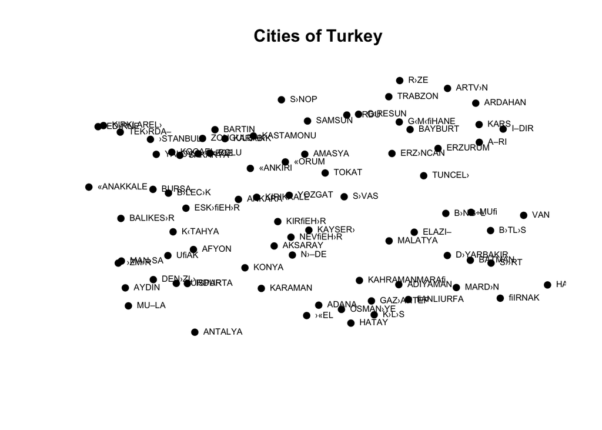

```r
plot(x_t1, y_t1, pch = 19, xlab = "", ylab = "", axes = F, main = "Cities of Turkey")
text(x_t1, y_t1, pos = 4, cex = 0.6, labels = colnames(df_t1))
```

As an interesting result, plot shapes the map of Turkey with dots representing cities. Cities are almost on their exact locations.

# 3 TASK 2

Importing the Netflix rating data and movie titles

```r
df_t2 <- read.table("HW2_q3_Netflix_data.dat", header=FALSE)
head(df_t2)
```

```
##   V1 V2 V3 V4 V5 V6 V7 V8 V9 V10 V11 V12 V13 V14 V15 V16 V17 V18 V19 V20 V21
## 1  4  4  5  4  5  3  5  5  5   4   5   3   5   3   4   5   5   5   5   5   4
## 2  4  4  5  4  5  4  5  5  2   5   5   5   3   4   5   0   5   4   5   4   5
## 3  3  4  4  4  5  5  4  4  3   3   4   3   4   3   3   3   4   4   5   3   4
## 4  3  4  4  3  5  4  4  4  4   4   3   3   4   4   3   0   1   4   3   3   4
## 5  5  5  5  4  5  4  5  5  4   5   4   4   5   5   5   5   4   4   5   4   4
## 6  5  4  5  2  4  5  5  4  4   4   5   3   5   5   4   0   4   4   3   3   5
##   V22 V23 V24 V25 V26 V27 V28 V29 V30 V31 V32 V33 V34 V35 V36 V37 V38 V39 V40
## 1   4   3   5   3   4   5   4   5   5   4   4   5   4   5   5   5   3   5   4
## 2   4   4   4   0   5   5   4   5   3   3   4   5   0   5   4   5   0   4   5
## 3   3   4   5   2   5   4   4   0   0   5   5   0   0   4   3   3   0   4   4
## 4   4   4   4   0   4   3   3   5   4   5   3   3   3   3   4   3   0   4   3
## 5   5   5   4   0   3   3   5   5   4   5   5   4   3   5   4   0   3   5   3
## 6   0   3   3   2   5   4   0   5   5   3   4   5   0   3   2   2   2   0   3
##   V41 V42 V43 V44 V45 V46 V47 V48 V49 V50 V51 V52 V53 V54 V55 V56 V57 V58 V59
```

[output cut: 27 more lines]

```r
titles_t2 <- read_delim("HW2_q3_movie_titles.txt", delim = "/", col_names = FALSE)
head(titles_t2)
```

```
## # A tibble: 6 x 1
##   X1
##   <chr>
## 1 2000,Miss Congeniality
## 2 1996,Independence Day
## 3 2000,The Patriot
## 4 2004,The Day After Tomorrow
## 5 2003,Pirates of the Caribbean: The Curse of the Black Pearl
## 6 1990,Pretty Woman
```

Checking missing values. It can be seen that there are not any missing values. So I assume that 0 ratings show the movie which are not rated by that user. I manipulate the data and change the **0** values to **NA**.

```r
df_t2[is.na(df_t2)]
```

```
## numeric(0)
```

```r
df_t2[df_t2==0] <- NA
head(df_t2)
```

```
##   V1 V2 V3 V4 V5 V6 V7 V8 V9 V10 V11 V12 V13 V14 V15 V16 V17 V18 V19 V20 V21
## 1  4  4  5  4  5  3  5  5  5   4   5   3   5   3   4   5   5   5   5   5   4
## 2  4  4  5  4  5  4  5  5  2   5   5   5   3   4   5  NA   5   4   5   4   5
## 3  3  4  4  4  5  5  4  4  3   3   4   3   4   3   3   3   4   4   5   3   4
## 4  3  4  4  3  5  4  4  4  4   4   3   3   4   4   3  NA   1   4   3   3   4
## 5  5  5  5  4  5  4  5  5  4   5   4   4   5   5   5   5   4   4   5   4   4
## 6  5  4  5  2  4  5  5  4  4   4   5   3   5   5   4  NA   4   4   3   3   5
##   V22 V23 V24 V25 V26 V27 V28 V29 V30 V31 V32 V33 V34 V35 V36 V37 V38 V39 V40
## 1   4   3   5   3   4   5   4   5   5   4   4   5   4   5   5   5   3   5   4
## 2   4   4   4  NA   5   5   4   5   3   3   4   5  NA   5   4   5  NA   4   5
## 3   3   4   5   2   5   4   4  NA  NA   5   5  NA  NA   4   3   3  NA   4   4
## 4   4   4   4  NA   4   3   3   5   4   5   3   3   3   3   4   3  NA   4   3
## 5   5   5   4  NA   3   3   5   5   4   5   5   4   3   5   4  NA   3   5   3
## 6  NA   3   3   2   5   4  NA   5   5   3   4   5  NA   3   2   2   2  NA   3
##   V41 V42 V43 V44 V45 V46 V47 V48 V49 V50 V51 V52 V53 V54 V55 V56 V57 V58 V59
```

[output cut: 27 more lines]

Imputing missing entries with the mean of the ratings for a particular movie

```r
df_t2 %<>% mutate_all(~ifelse(is.na(.x), mean(.x, na.rm = TRUE), .x))
head(df_t2)
```

```
##   V1 V2 V3 V4 V5 V6 V7 V8 V9 V10 V11 V12 V13 V14 V15      V16 V17 V18 V19 V20
## 1  4  4  5  4  5  3  5  5  5   4   5   3   5   3   4 5.000000   5   5   5   5
## 2  4  4  5  4  5  4  5  5  2   5   5   5   3   4   5 3.638086   5   4   5   4
## 3  3  4  4  4  5  5  4  4  3   3   4   3   4   3   3 3.000000   4   4   5   3
## 4  3  4  4  3  5  4  4  4  4   4   3   3   4   4   3 3.638086   1   4   3   3
## 5  5  5  5  4  5  4  5  5  4   5   4   4   5   5   5 5.000000   4   4   5   4
## 6  5  4  5  2  4  5  5  4  4   4   5   3   5   5   4 3.638086   4   4   3   3
##   V21      V22 V23 V24     V25 V26 V27     V28      V29      V30 V31 V32
## 1   4 4.000000   3   5 3.00000   4   5 4.00000 5.000000 5.000000   4   4
## 2   5 4.000000   4   4 2.87492   5   5 4.00000 5.000000 3.000000   3   4
## 3   4 3.000000   4   5 2.00000   5   4 4.00000 4.481826 4.538585   5   5
## 4   4 4.000000   4   4 2.87492   4   3 3.00000 5.000000 4.000000   5   3
## 5   4 5.000000   5   4 2.87492   3   3 5.00000 5.000000 4.000000   5   5
## 6   5 3.765544   3   3 2.00000   5   4 3.68503 5.000000 5.000000   3   4
##        V33      V34 V35 V36      V37      V38      V39 V40      V41 V42
```

[output cut: 48 more lines]

Creating euclidean distance matrix from the rating data by taking means of ratings for each movie

```r
df_t2_dist_matrix <- dist(t(df_t2), method = "euclidean", upper = TRUE)
```

Applying multidimensional scaling (MDS)

```r
df_t2_fit <- cmdscale(df_t2_dist_matrix, k = 2, eig = TRUE)
df_t2_fit
```

```
## $points
##             [,1]        [,2]
## V1    33.7884320 -36.5063480
## V2   -25.0588503 -16.6909210
## V3   -22.9912948 -19.9723714
## V4    24.0263147 -27.8072475
## V5   -45.7938316   1.7561607
## V6   -16.1564386 -24.0296352
## V7   -64.9857950   7.1083499
## V8   -57.2946407  -5.9049993
## V9    18.9435323 -22.4015626
## V10   15.4054434 -23.9520651
## V11   26.5529695 -34.8653223
## V12   19.1809367 -43.9171859
## V13  -11.2810821 -30.0946662
## V14  -12.2195171 -12.8617281
## V15   22.2428359 -27.8915459
## V16   28.5191748  -5.9304333
## V17  -13.1313459   8.0240100
## V18  -16.6042856   1.9061584
## V19   -2.4008223  -5.6716276
## V20   -3.2005279 -12.2262508
## V21   18.3199958  51.3821803
## V22   17.9289848 -28.8830131
## V23   14.4561627 -17.6807783
## V24  -40.6023850  -0.5043874
## V25  104.3191452  56.3998683
## V26  -23.7774409  -7.8875787
## V27    4.8227224  60.8335614
## V28   25.4114080 -22.0336321
## V29  -60.3278552   6.0608163
## V30  -68.8795548  14.7900447
## V31   -6.9108610 -20.4363764
## V32  -54.8302477   9.1442891
## V33  -65.8216433  16.6916747
## V34   54.9376319 -20.0949562
## V35   15.3666995 -25.0068022
## V36   42.7173746 -20.8768779
## V37   -0.9092954 -14.4405714
## V38  117.8488768  59.0406598
```

[output cut: 92 more lines]

```
##  [85]   3319.29309496698078874   3225.71583260252509717   3200.01394410927241552
##  [88]   3177.29345431650881437   3133.24660923823375924   3069.55322156492957220
##  [91]   3003.30641205047140829   2866.92654463182998370   2763.68687373608554481
##  [94]   2681.18532605907694233   2600.47103555677267650   2546.91666067592359468
##  [97]   1984.49858855982120076   1923.76114648532757201   1589.34500065534666646
## [100]     -0.00000000001009839
##
## $x
## NULL
##
## $ac
## [1] 0
##
## $GOF
## [1] 0.2942069 0.2942069
```

```r
x_t2 <- df_t2_fit$points[, 1]
y_t2 <- df_t2_fit$points[, 2]
```

Representing movies on a 2D plot using the reduced dimensions

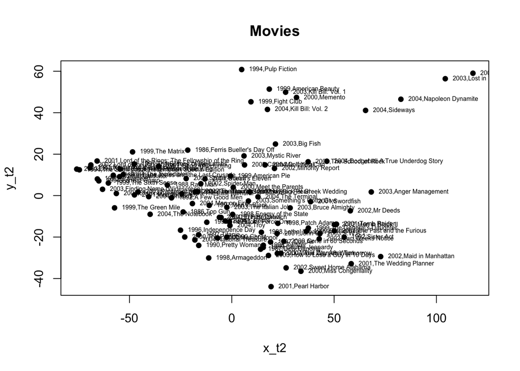

```r
plot(x_t2, y_t2, pch = 16, main = "Movies")
text(x_t2, y_t2, pos = 4, cex = 0.5, labels = titles_t2$X1)
```

As an interesting result, the movies which are in the IMDB top 250 list are generally located nearly and on the left side of the plot. Moreover, the movie series are located nearly like Kill Bill, Lord of the Rings, Spider-Man, Shrek etc.

# 4 TASK 3

Importing the dataset

```r
df_t3_x <- read.table("uWaveGestureLibrary_X_TRAIN", header=FALSE)
df_t3_y <- read.table("uWaveGestureLibrary_Y_TRAIN", header=FALSE)
df_t3_z <- read.table("uWaveGestureLibrary_Z_TRAIN", header=FALSE)
```

Data manipulation by converting data to long format (as an example first 6 rows of X axis data shown)

```r
df_t3_x_long <- df_t3_x %>%
  as_tibble() %>%
  mutate(time_series_id = row_number()) %>%
  rename(class = V1) %>%
  pivot_longer(cols = -c(time_series_id, class), names_to = "time_index", values_to = "X")

df_t3_y_long <- df_t3_y %>%
  as_tibble() %>%
  mutate(time_series_id = row_number()) %>%
  rename(class = V1) %>%
  pivot_longer(cols = -c(time_series_id, class), names_to = "time_index", values_to = "Y")

df_t3_z_long <- df_t3_z %>%
  as_tibble() %>%
  mutate(time_series_id = row_number()) %>%
  rename(class = V1) %>%
  pivot_longer(cols = -c(time_series_id, class), names_to = "time_index", values_to = "Z")

head(df_t3_x_long)
```

```
## # A tibble: 6 x 4
##   class time_series_id time_index      X
##   <dbl>          <int> <chr>       <dbl>
## 1     6              1 V2         -0.304
## 2     6              1 V3         -0.304
## 3     6              1 V4         -0.304
## 4     6              1 V5         -0.304
## 5     6              1 V6         -0.304
## 6     6              1 V7         -0.304
```

Binding columns to concatenate the time series of X, Y and Z axis. Summary of X, Y, Z columns are shown below.

```r
df_t3_long <- bind_cols(df_t3_x_long, Y = df_t3_y_long$Y, Z = df_t3_z_long$Z) %>%
  mutate(class = as.factor(class))
head(df_t3_long)
```

```
## # A tibble: 6 x 6
##   class time_series_id time_index      X     Y     Z
##   <fct>          <int> <chr>       <dbl> <dbl> <dbl>
## 1 6                  1 V2         -0.304 -2.12 -1.53
## 2 6                  1 V3         -0.304 -2.12 -1.53
## 3 6                  1 V4         -0.304 -2.12 -1.53
## 4 6                  1 V5         -0.304 -2.12 -1.53
## 5 6                  1 V6         -0.304 -2.12 -1.53
## 6 6                  1 V7         -0.304 -2.12 -1.53
```

```r
summary(df_t3_long %>% select(X,Y,Z))
```

```
##        X                   Y                  Z
##  Min.   :-4.438255   Min.   :-4.10337   Min.   :-3.54840
##  1st Qu.:-0.794170   1st Qu.:-0.83305   1st Qu.:-0.80436
##  Median :-0.007178   Median :-0.01425   Median :-0.01722
##  Mean   : 0.000000   Mean   : 0.00000   Mean   : 0.00000
##  3rd Qu.: 0.781666   3rd Qu.: 0.79252   3rd Qu.: 0.77923
##  Max.   : 4.434067   Max.   : 7.65402   Max.   : 4.77860
```

Selecting one instance from each class

```r
df_t3_class_1 <- df_t3_long %>% filter(time_series_id == 11 )
df_t3_class_2 <- df_t3_long %>% filter(time_series_id == 15 )
df_t3_class_3 <- df_t3_long %>% filter(time_series_id == 4 )
df_t3_class_4 <- df_t3_long %>% filter(time_series_id == 5 )
df_t3_class_5 <- df_t3_long %>% filter(time_series_id == 2 )
df_t3_class_6 <- df_t3_long %>% filter(time_series_id == 1 )
df_t3_class_7 <- df_t3_long %>% filter(time_series_id == 7 )
df_t3_class_8 <- df_t3_long %>% filter(time_series_id == 6 )
```

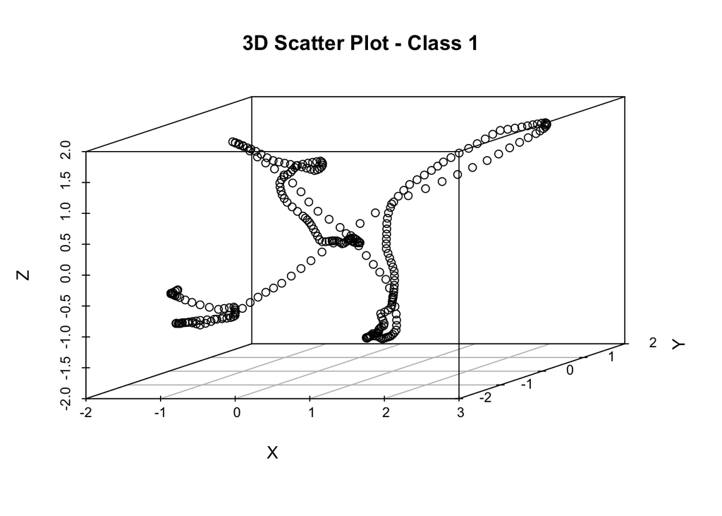

```r
scatterplot3d(x=df_t3_class_1$X,
              y=df_t3_class_1$Y,
              z=df_t3_class_1$Z,
              main = "3D Scatter Plot - Class 1",
              xlab = "X",
              ylab = "Y",
              zlab = "Z")
```

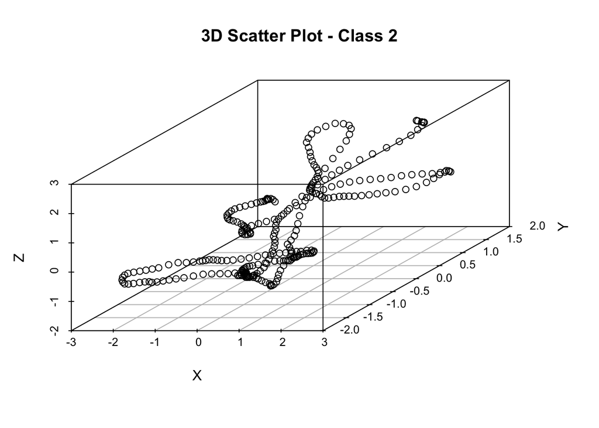

```r
scatterplot3d(x=df_t3_class_2$X,
              y=df_t3_class_2$Y,
              z=df_t3_class_2$Z,
              main = "3D Scatter Plot - Class 2",
              xlab = "X",
              ylab = "Y",
              zlab = "Z")
```

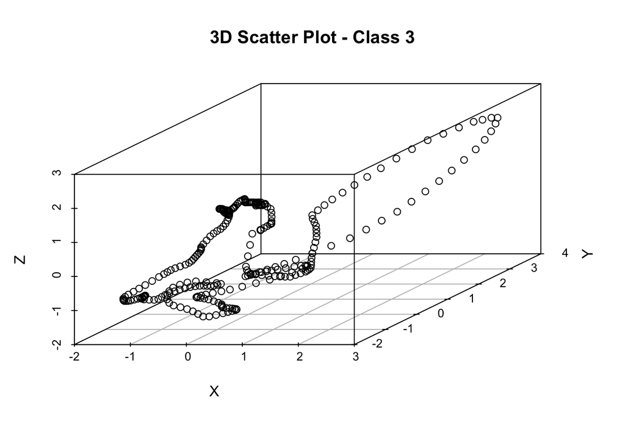

```r
scatterplot3d(x=df_t3_class_3$X,
              y=df_t3_class_3$Y,
              z=df_t3_class_3$Z,
              main = "3D Scatter Plot - Class 3",
              xlab = "X",
              ylab = "Y",
              zlab = "Z")
```

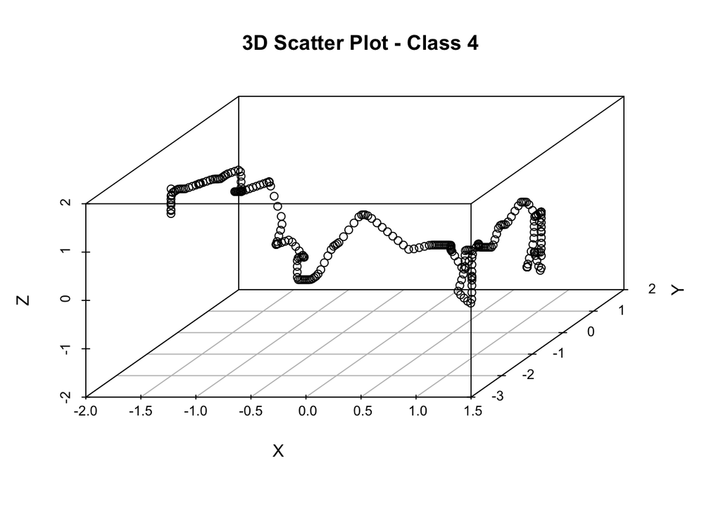

```r
scatterplot3d(x=df_t3_class_4$X,
              y=df_t3_class_4$Y,
              z=df_t3_class_4$Z,
              main = "3D Scatter Plot - Class 4",
              xlab = "X",
              ylab = "Y",
              zlab = "Z")
```

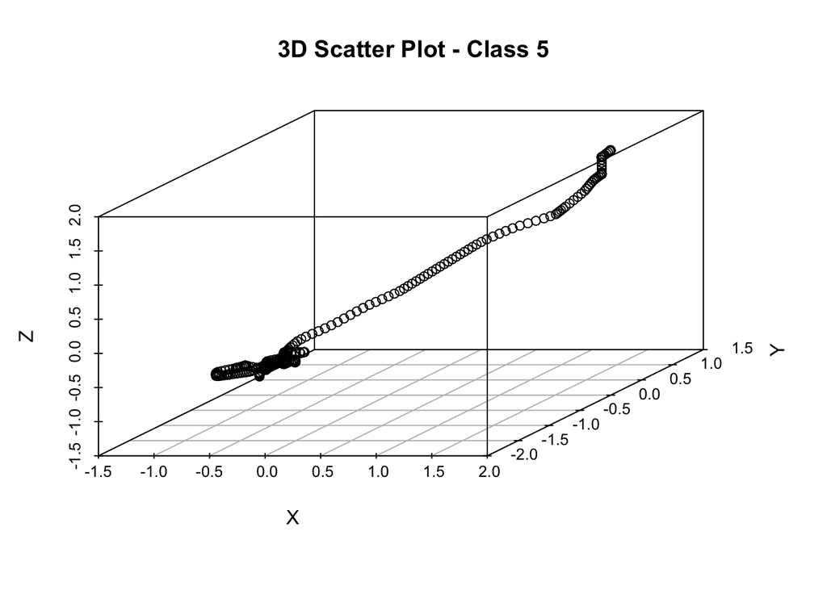

```r
scatterplot3d(x=df_t3_class_5$X,
              y=df_t3_class_5$Y,
              z=df_t3_class_5$Z,
              main = "3D Scatter Plot - Class 5",
              xlab = "X",
              ylab = "Y",
              zlab = "Z")
```

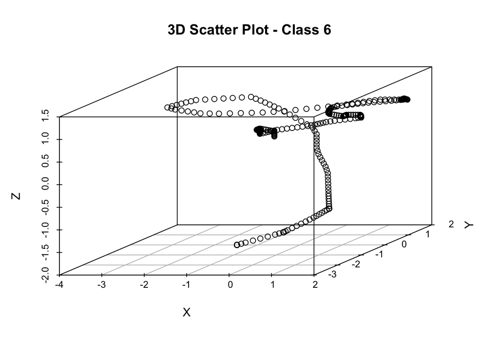

```r
scatterplot3d(x=df_t3_class_6$X,
              y=df_t3_class_6$Y,
              z=df_t3_class_6$Z,
              main = "3D Scatter Plot - Class 6",
              xlab = "X",
              ylab = "Y",
              zlab = "Z")
```

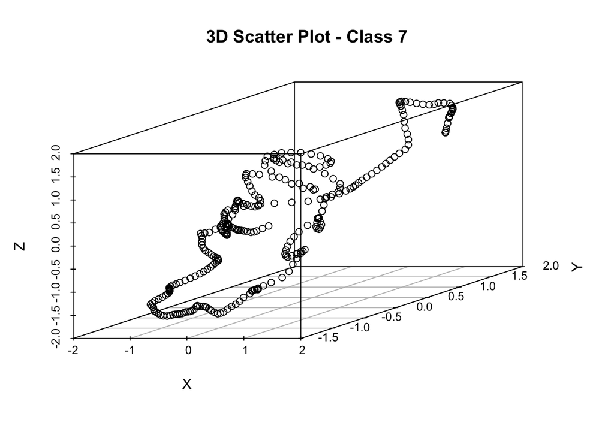

```r
scatterplot3d(x=df_t3_class_7$X,
              y=df_t3_class_7$Y,
              z=df_t3_class_7$Z,
              main = "3D Scatter Plot - Class 7",
              xlab = "X",
              ylab = "Y",
              zlab = "Z")
```

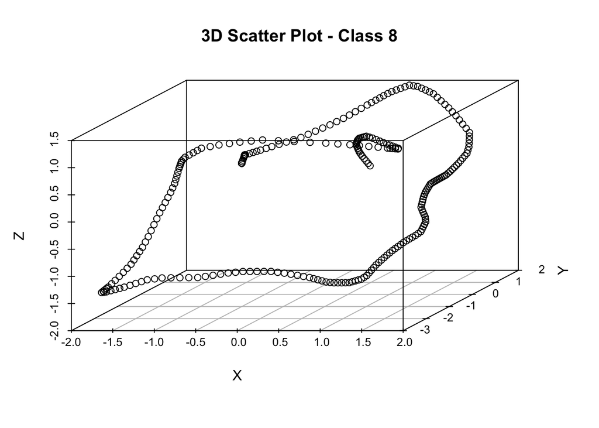

```r
scatterplot3d(x=df_t3_class_8$X,
              y=df_t3_class_8$Y,
              z=df_t3_class_8$Z,
              main = "3D Scatter Plot - Class 8",
              xlab = "X",
              ylab = "Y",
              zlab = "Z")
```

Applying PCA (Subtask b)

```r
df_t3_pca <- princomp(df_t3_long %>% filter(time_series_id %in% c(1,2,4,5,6,7,11,15)) %>%  select(X,Y,Z), cor = T)
summary(df_t3_pca, loadings = T)
```

```
## Importance of components:
##                           Comp.1    Comp.2   Comp.3
## Standard deviation     1.2954714 0.8683529 0.753470
## Proportion of Variance 0.5594154 0.2513456 0.189239
## Cumulative Proportion  0.5594154 0.8107610 1.000000
##
## Loadings:
##   Comp.1 Comp.2 Comp.3
## X  0.555  0.695  0.457
## Y  0.624        -0.781
## Z  0.550 -0.719  0.425
```

Plotting variances of components. From the plot, it can be seen that most of the variance covered by the first 2 components.

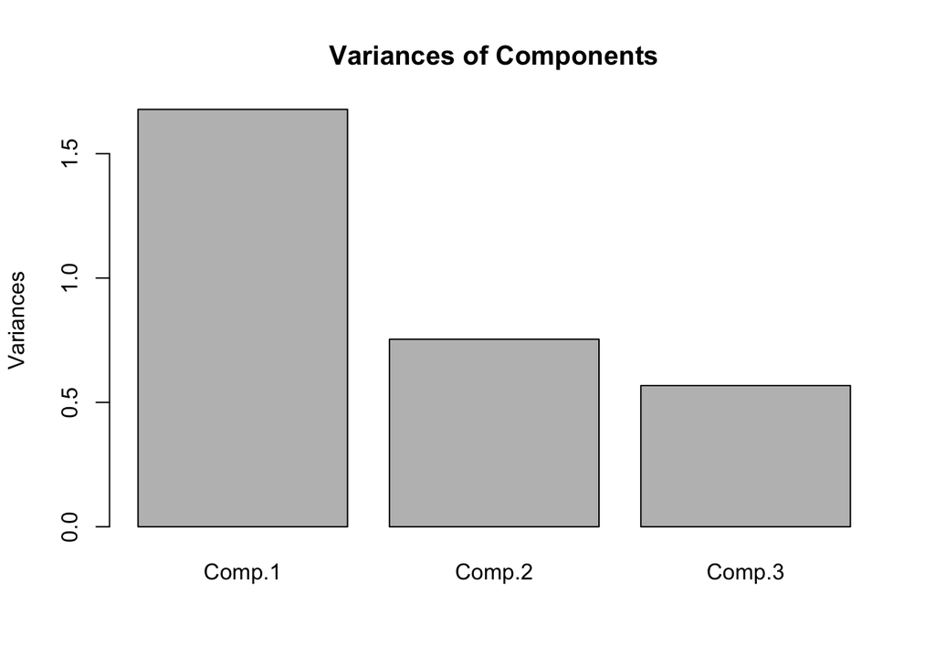

```r
plot(df_t3_pca, type = "b", main = "Variances of Components")
```

Component 1 covers **55.94%** of the variance and Component 2 covers **25.13%** of the variance. Thus, in total, **81.07%** of the variance are covered by the two dimensions.

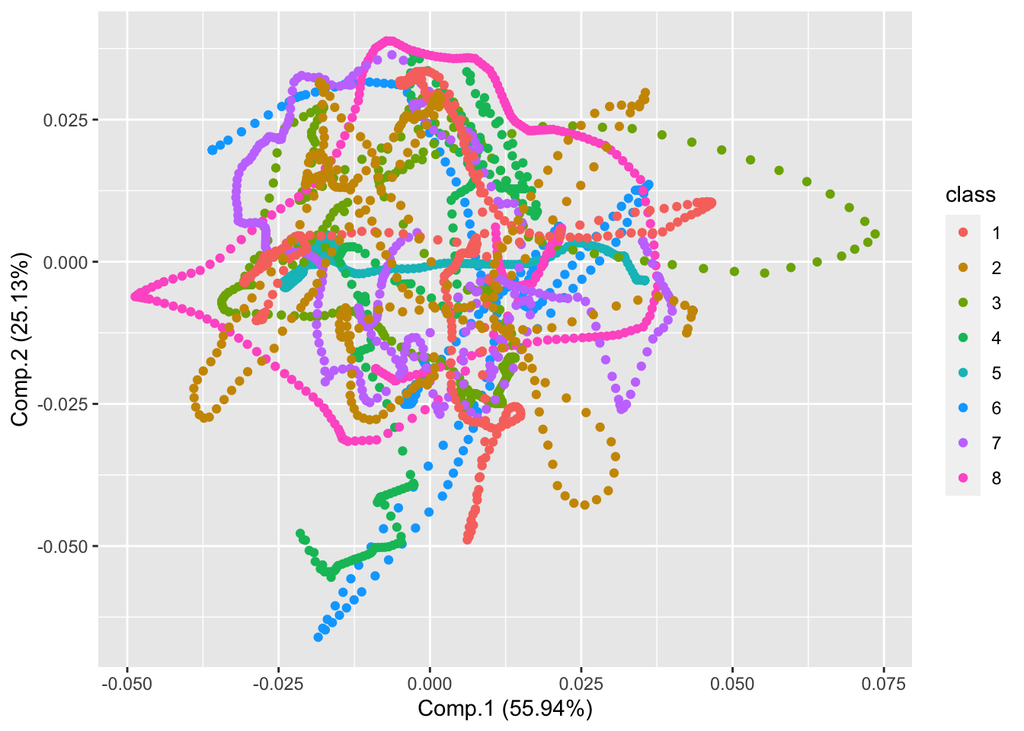

```r
autoplot(df_t3_pca, data = df_t3_long %>% filter(time_series_id %in% c(1,2,4,5,6,7,11,15)), colour = "class")
```